# Running Around R with Marathons

Jessica Alexander

### On your marks, get set, go!

Starting with a quick exploration to see what we’re working with. Here are the first six rows of our dataset:

```
##   year             winner gender  country     time marathon
## 1 2018     Dickson Chumba   Male    Kenya 02:05:30    Tokyo
## 2 2018     Birhane Dibaba Female Ethiopia 02:19:51    Tokyo
## 3 2017     Wilson Kipsang   Male    Kenya 02:03:58    Tokyo
## 4 2017 Sarah Chepchirchir Female    Kenya 02:19:47    Tokyo
## 5 2016      Feyisa Lilesa   Male Ethiopia 02:06:56    Tokyo
## 6 2016       Helah Kiprop Female    Kenya 02:21:27    Tokyo
```

And here are details of the data available in each column:

```
## 'data.frame':    536 obs. of  6 variables:
##  $ year    : int  2018 2018 2017 2017 2016 2016 2015 2015 2014 2014 ...
##  $ winner  : chr  "Dickson Chumba" "Birhane Dibaba" "Wilson Kipsang" "Sarah Chepchirchir" ...
##  $ gender  : chr  "Male" "Female" "Male" "Female" ...
##  $ country : chr  "Kenya" "Ethiopia" "Kenya" "Kenya" ...
##  $ time    : chr  "02:05:30" "02:19:51" "02:03:58" "02:19:47" ...
##  $ marathon: chr  "Tokyo" "Tokyo" "Tokyo" "Tokyo" ...
```

(Under the hood, I’m doing a quick check for missing data. Good news, no missing values!)

First, then, let’s fix the `$gender` and `$marathon` columns to make them into factors, and check out the details of each.

```
## Female   Male
##    233    303
```

```
##  Berlin  Boston Chicago  London     NYC   Tokyo
##      88     175      80      77      92      24
```

Next, let’s convert winning times from hh:mm:ss to total seconds to make it more usable.

```
##    Min. 1st Qu.  Median    Mean 3rd Qu.    Max.
##    7377    7783    8468    8490    8856   12600
```

Is that `12600` accurate? [Sure is](https://en.wikipedia.org/wiki/List_of_winners_of_the_Boston_Marathon#Women's_open_division)!

Ok, what about our overall time frame?

```
##    Min. 1st Qu.  Median    Mean 3rd Qu.    Max.
##    1897    1980    1993    1988    2007    2018
```

Hmm… We might want to plot chronology, but the original dataset doesn’t include which month each race typically takes place, so let’s add that. Both Boston and London typically take place in April, but Boston is usually first, so we’ll make London “4.5” to Boston’s “4”.

```
##         2   4 4.5   9  10  11
## name  Feb Apr Apr Sep Oct Nov
## count  24 175  77  88  80  92
```

We should probably tease apart the men’s results from the women’s, so let’s create two separate dataframes and re-order them chronologically.

#### **Women**

```
##       year         winner             gender      country
##  Min.   :1966   Length:233         Female:233   Length:233
##  1st Qu.:1985   Class :character   Male  :  0   Class :character
##  Median :1997   Mode  :character                Mode  :character
##  Mean   :1996
##  3rd Qu.:2008
##  Max.   :2018
##       time          marathon  month
##  Min.   : 8125   Berlin :44   2  :12
##  1st Qu.: 8595   Boston :54   4  :54
##  Median : 8756   Chicago:40   4.5:38
##  Mean   : 9021   London :38   9  :44
##  3rd Qu.: 9022   NYC    :45   10 :40
##  Max.   :12600   Tokyo  :12   11 :45
```

#### **Men**

```
##       year         winner             gender      country
##  Min.   :1897   Length:303         Female:  0   Length:303
##  1st Qu.:1972   Class :character   Male  :303   Class :character
##  Median :1990   Mode  :character                Mode  :character
##  Mean   :1981
##  3rd Qu.:2005
##  Max.   :2018
##       time          marathon   month
##  Min.   : 7377   Berlin : 44   2  : 12
##  1st Qu.: 7676   Boston :121   4  :121
##  Median : 7811   Chicago: 40   4.5: 39
##  Mean   : 8081   London : 39   9  : 44
##  3rd Qu.: 8349   NYC    : 47   10 : 40
##  Max.   :10510   Tokyo  : 12   11 : 47
```

Finally, it’s time for a visual!

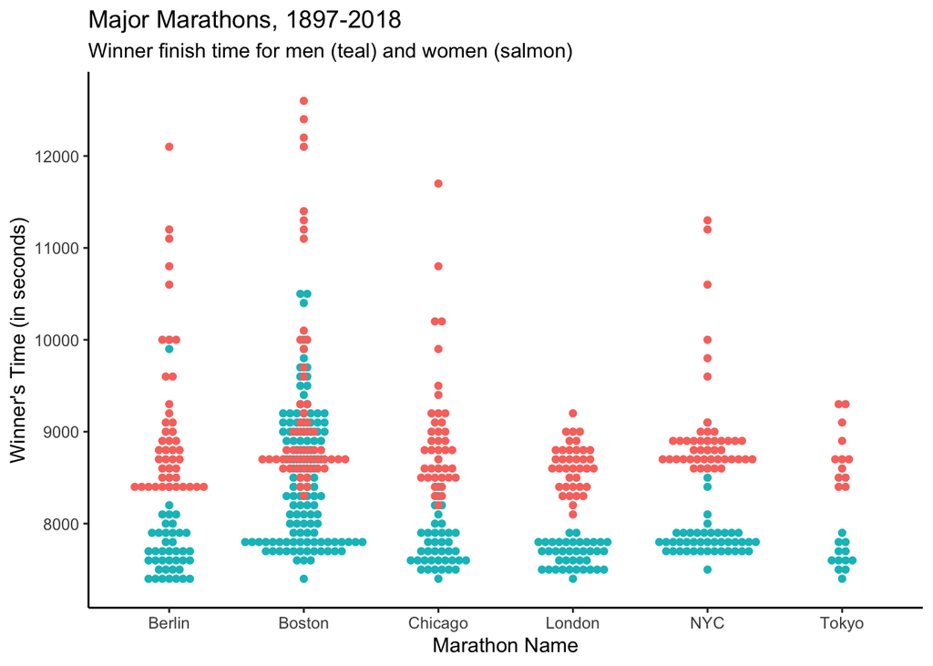

We already knew that we had way more data for Boston, but the historical overlap in male v. female times is interesting. Let’s look at a density chart for another perspective:

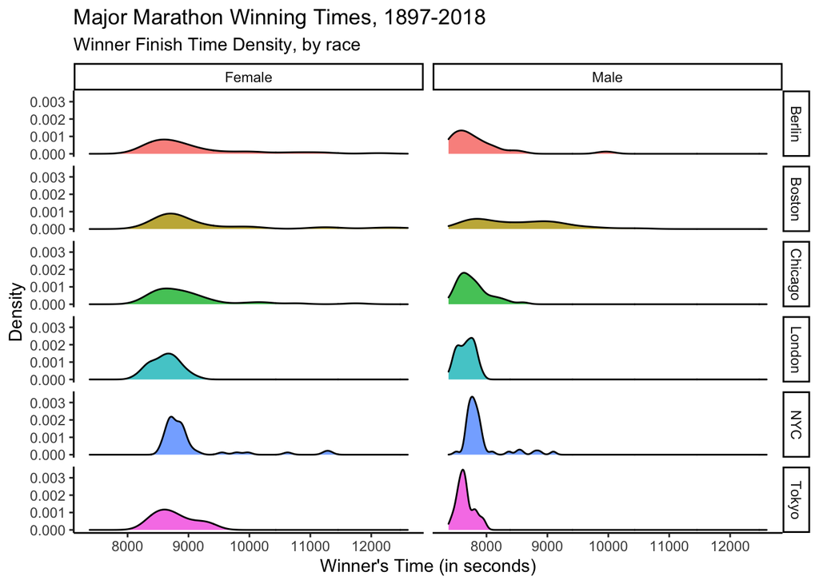

Men’s finish times at Boston span a wide and relatively even range. Let’s look at them by year, side-by-side with the women’s finishes.

[figure not shown]

Wow, the women were killing it in the 70s! :)

Now, suspend disbelief with me, if you will, and imagine that this data meets randomization requirements for standard statistical tests. Everyone seems to be getting faster, but the women are doing so at a greater velocity. I wonder if women were as fast in the past 20 years of racing to Boston’s Copley Square as their male counterparts were 100 years earlier? Let’s start with two quick visuals:

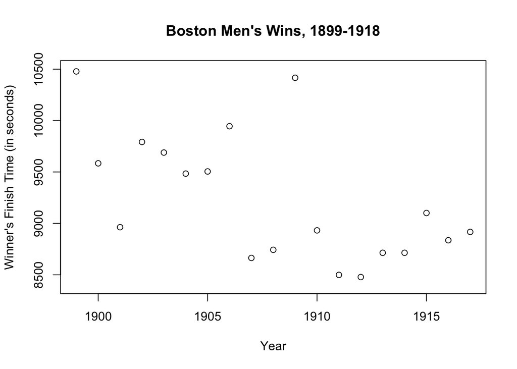

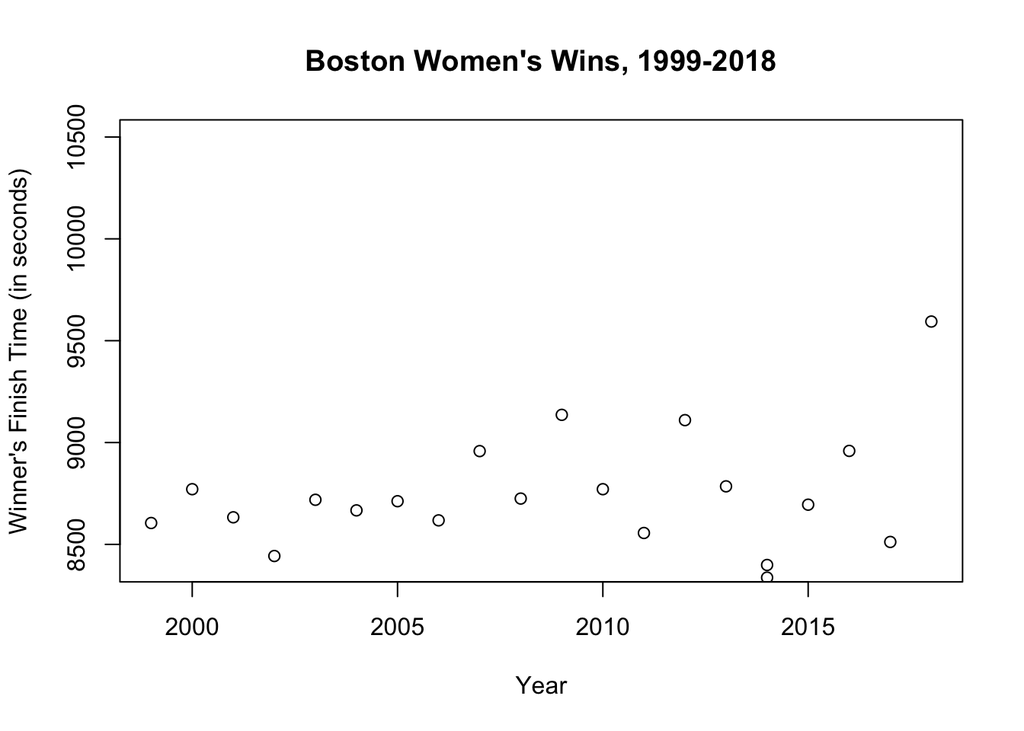

Hmm, hard to tell from those scatterplots…maybe a boxplot will help?

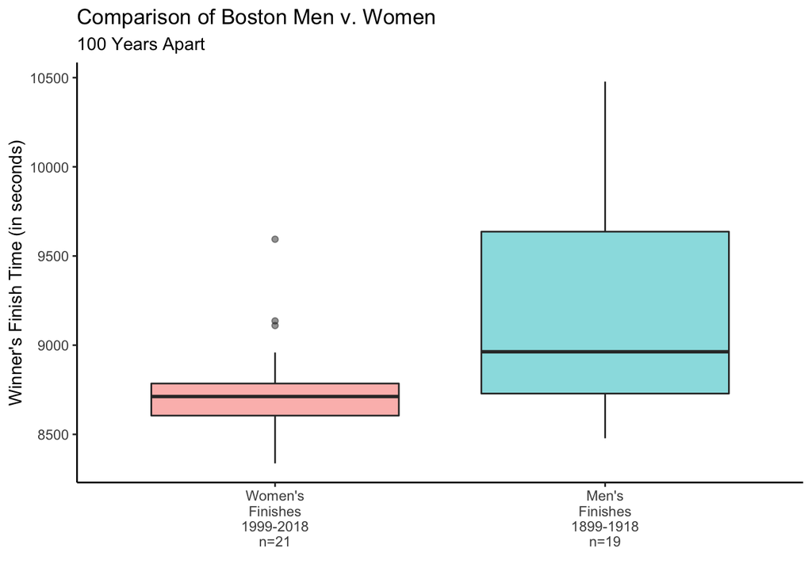

It does look like the women of 1999-2018 were faster than the men of 1899-1918, but let’s confirm that with an easy test.

```
##
##  Wilcoxon rank sum test with continuity correction
##
## data:  women_boston_1999_2018$time and men_boston_1899_1918$time
## W = 101, p-value = 0.007943
## alternative hypothesis: true location shift is not equal to 0
```

Not a terribly useful bit of information that we’ve established here given that we’re on shaky statistical ground, but pretty cool fun fact to drop at a cocktail party?

What else can we explore? The Kenyans are known for dominating the international marathoning world, right?

```
##      Australia        Belgium         Brazil         Canada          China
##              3              5              7             17              1
##       Colombia        Denmark        Eritrea       Ethiopia        Finland
##              2              2              1             51             10
##        Germany         Greece      Guatemala        Hungary        Ireland
##             36              2              1              1              3
##          Italy          Japan          Kenya         Latvia         Mexico
##              6             22            136              2             10
##        Morocco    New Zealand         Norway         Poland       Portugal
##              5              5             20              8             11
##        Romania         Russia   South Africa    South Korea   Soviet Union
##              2              8              5              3              1
##          Spain         Sweden    Switzerland       Tanzania United Kingdom
##              2              2              2              4             35
##  United States     Yugoslavia
##            104              1
```

Wow! 136 wins in this dataset! Let’s zoom in on this…

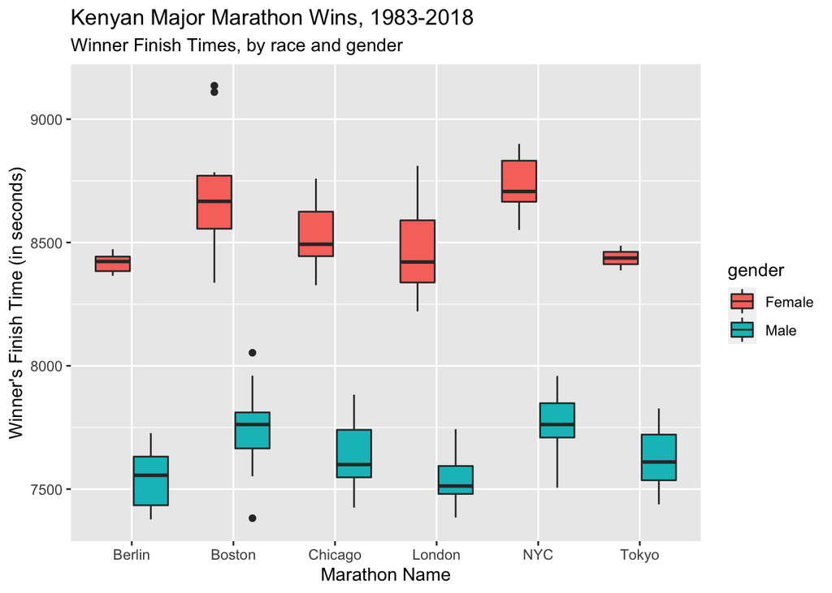

It looks like the Kenyan men have high variability in finish times across races, but the women are pretty consistent; let’s confirm with a Kruskal-Wallis test.

```
##              no_of_races chi_squared df  p_value
## kenyan_men            88    33.77171  5 0.000003
## kenyan_women          48    19.04452  5 0.001886
```

Nope, still plenty of variability in the Kenyan women across these races!  
Are you still suspending disbelief with me? Great, because it’s time for a ridiculous ANOVA! Close your eyes while I check some standard assumptions, even though we’re ignoring statistical reliability here…

##### Checking number of observations per group:

```
##              Boston NYC Chicago London Berlin Tokyo
## kenyan_men       21  14      16     14     16     7
## kenyan_women     13  10       7     11      5     2
```

##### Checking normality per group with Shapiro p-values:

(I’m zeroing out Tokyo wins for Kenyan women since there were only two observations.)

```
##                Boston      NYC  Chicago   London   Berlin   Tokyo
## kenyan_men   0.499855 0.426515 0.373987 0.525133 0.123027 0.74797
## kenyan_women 0.279985 0.352261 0.917439 0.791520 0.866477 0.00000
```

##### Checking homogeneity of variance per group:

```
##                Boston      NYC  Chicago    London    Berlin     Tokyo
## kenyan_men   140.3152 109.7163 136.3852  96.73176 114.13559 140.53944
## kenyan_women 230.1501 113.4844 148.5939 179.29159  43.70126  70.71068
```

Ok, we’re really far out on a precarious limb here and absolutely shouldn’t be running any more statistical tests today since none of the right assumptions are in place…but we have to see this crazy ANOVA to its ridiculous conclusion!

```
##                  Df   Sum Sq  Mean Sq  F value Pr(>F)
## marathon          5  2960470   592094   29.570 <2e-16 ***
## gender            1 25809655 25809655 1288.957 <2e-16 ***
## marathon:gender   5    47168     9434    0.471  0.797
## Residuals       124  2482936    20024
## ---
## Signif. codes:  0 '***' 0.001 '**' 0.01 '*' 0.05 '.' 0.1 ' ' 1
```

Unsurprisingly, we have main effects for gender and host city, but no interaction effect between those two variables. (I mean, if we hadn’t thrown basic stats out the window hundreds of lines of code ago…) Here is a final visual to wrap things up!

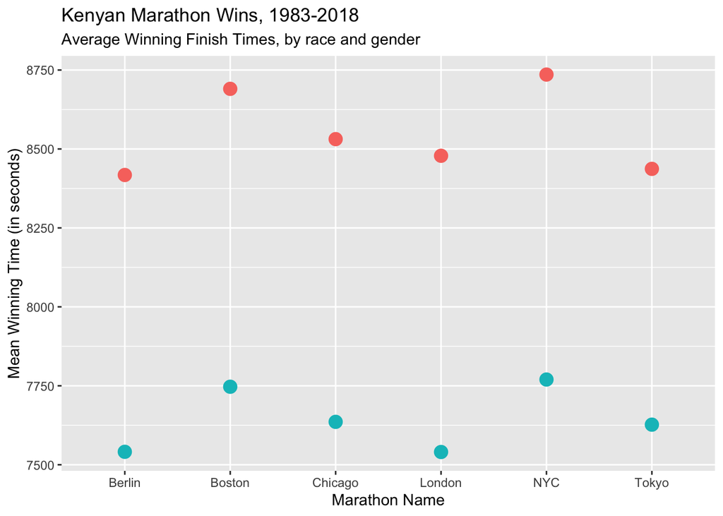